# Cross-Validation

James Muguira

May 23, 2016

We are going to work on Cross-Validation. Please read chapter 5 of An Introduction to Statistical Learning in R.

I’ll work with the Auto data set. It is similar to mtcars.

*1st, I’ll introduce some concepts in the slides.*

*2nd, I’ll work through a traditional linear model*

*3rd, Explain assumptions*

*4th, Attack the problem with Bootstrapping*

*5th, Compare*

# Traditional Linear Model

Using the Auto data set of 392 observations about cars. Find a linear model and investigate the model.

```r
library(ISLR)
data("Auto")
library(boot)
str(Auto)
```

```
## 'data.frame':    392 obs. of  9 variables:
##  $ mpg         : num  18 15 18 16 17 15 14 14 14 15 ...
##  $ cylinders   : num  8 8 8 8 8 8 8 8 8 8 ...
##  $ displacement: num  307 350 318 304 302 429 454 440 455 390 ...
##  $ horsepower  : num  130 165 150 150 140 198 220 215 225 190 ...
##  $ weight      : num  3504 3693 3436 3433 3449 ...
##  $ acceleration: num  12 11.5 11 12 10.5 10 9 8.5 10 8.5 ...
##  $ year        : num  70 70 70 70 70 70 70 70 70 70 ...
##  $ origin      : num  1 1 1 1 1 1 1 1 1 1 ...
##  $ name        : Factor w/ 304 levels "amc ambassador brougham",..: 49 36 231 14 161 141 54 223 241 2 ...
```

```r
cor(Auto[1:8])
```

```
##                     mpg  cylinders displacement horsepower     weight
## mpg           1.0000000 -0.7776175   -0.8051269 -0.7784268 -0.8322442
## cylinders    -0.7776175  1.0000000    0.9508233  0.8429834  0.8975273
## displacement -0.8051269  0.9508233    1.0000000  0.8972570  0.9329944
## horsepower   -0.7784268  0.8429834    0.8972570  1.0000000  0.8645377
## weight       -0.8322442  0.8975273    0.9329944  0.8645377  1.0000000
## acceleration  0.4233285 -0.5046834   -0.5438005 -0.6891955 -0.4168392
## year          0.5805410 -0.3456474   -0.3698552 -0.4163615 -0.3091199
## origin        0.5652088 -0.5689316   -0.6145351 -0.4551715 -0.5850054
##              acceleration       year     origin
## mpg             0.4233285  0.5805410  0.5652088
## cylinders      -0.5046834 -0.3456474 -0.5689316
## displacement   -0.5438005 -0.3698552 -0.6145351
## horsepower     -0.6891955 -0.4163615 -0.4551715
## weight         -0.4168392 -0.3091199 -0.5850054
## acceleration    1.0000000  0.2903161  0.2127458
## year            0.2903161  1.0000000  0.1815277
## origin          0.2127458  0.1815277  1.0000000
```

Casual investigation reveals that just like mtcars, Displacement, weight, horsepower, cylinders are all strongly correlated to mpg. If it was our job to produce a “best fit” model we would use these variables.

## A simpler model to work from

Let’s reduce the number of variables for a moment. Let’s model mpg as a function of just horsepower to make a point.

```r
Auto_lm2 = lm(mpg ~ horsepower, data=Auto)
summary(Auto_lm2)
```

```
##
## Call:
## lm(formula = mpg ~ horsepower, data = Auto)
##
## Residuals:
##      Min       1Q   Median       3Q      Max
## -13.5710  -3.2592  -0.3435   2.7630  16.9240
##
## Coefficients:
##              Estimate Std. Error t value Pr(>|t|)
## (Intercept) 39.935861   0.717499   55.66   <2e-16 ***
## horsepower  -0.157845   0.006446  -24.49   <2e-16 ***
## ---
## Signif. codes:  0 '***' 0.001 '**' 0.01 '*' 0.05 '.' 0.1 ' ' 1
##
## Residual standard error: 4.906 on 390 degrees of freedom
## Multiple R-squared:  0.6059, Adjusted R-squared:  0.6049
## F-statistic: 599.7 on 1 and 390 DF,  p-value: < 2.2e-16
```

This model describes about 60% of the variation in the data. Not a bad model.

However, there were a number of assumptions made when we decided to use linear regression to model this system:

- first, the linear model depends on us knowing the standard deviation (sigma^2). This assumption is not a problem IF the raw data is linear. However, if there is ANY non-linear component to the raw data we are glossing over it using linear models. This means our standard deviation is over estimated and this could cause problems with datasets that are small (few observations).
- All variation in the experiment that produced the data comes from the errors. Said another way we assume that we are perfect modelers and experiment builders and that chance is the only source of error/variation. This is not realistic with real-world data!!!

To arrive at this model we followed a process:

*Describe the dataset*

*Create a linear model from the data (using all the data)*

*Investigate the Standard Error (SE) and Mean Standard Error (MSE) to see if we can live with them.*

But our process just takes one pass on the data. For these small datasets that might ok. We could use R’s step() function to try and improve the model fit. However, we are not using the data to our best advantage.

If we partition the data into a training and testing set we can compare and further refine the model fit by reducing the SE and MSE. That is where Cross-Validation would be used. You can read the sections in Chapter 5 of An Introduction to Statistical Learning in R (ISLR).

# Boot Strapping

Bootstrapping does not make these assumptions. This is one of the reasons it is so powerful. Boot Strapping works directly on the data to produce a best fit model.

To see boot strapping action let’s work through a few examples. The first example is also discussed in ISLR. We examine the Portfolio dataset.

```r
str(Portfolio)
```

```
## 'data.frame':    100 obs. of  2 variables:
##  $ X: num  -0.895 -1.562 -0.417 1.044 -0.316 ...
##  $ Y: num  -0.235 -0.885 0.272 -0.734 0.842 ...
```

Let’s implement equation 5.7 from ISLR for the Portfolio dataset.

```r
# this code is from An Introduction to Statistical Learning in R chapter 5
alpha.fn=function(data,index){
  X=data$X[index]
  Y=data$Y[index]
  return((var(Y)-cov(X,Y))/(var(X)+var(Y)-2*cov(X,Y)))
}
```

The Portfolio dataset gives us the returns on two fictional investments. We invest a fraction of our money alpha in X and the balance 1-alpha in investment Y. We are seeking to minimize the total risk (or maximize the total return) of our investment, alpha. Equation 5.7 is the formula to model that risk.

To use equation 5.7 to estimate the return for 1 single pass over the data we do the following:

```r
alpha.fn(Portfolio, 1:100)
```

```
## [1] 0.5758321
```

```r
# Sampling form the Portfolio dataset (replacement = T) produces, in effect a new data set with 100 # observations and a new alpha (our maximized return).

set.seed(1)
alpha.fn(Portfolio, sample(100, 100, replace=T))
```

```
## [1] 0.5963833
```

But we want to automate the process and search for a solution within a new dataset with 1000 samples. To do this we want to use the R boot function.

```r
boot(Portfolio, alpha.fn, R=1000)
```

```
##
## ORDINARY NONPARAMETRIC BOOTSTRAP
##
##
## Call:
## boot(data = Portfolio, statistic = alpha.fn, R = 1000)
##
##
## Bootstrap Statistics :
##      original        bias    std. error
## t1* 0.5758321 -7.315422e-05  0.08861826
```

So, our estimated return is 57% and our Standard Error (SE) is 8%. This is pretty good. But the power of bootstrapping comes in estimating the accuracy of our linear model.

# The Auto dataset revisited

```r
boot.fn=function(data, index) {
  return(coef(lm(mpg~horsepower, data=data, subset=index)))
}
```

Now let’s see how bootstrap preforms:

```r
boot(Auto, boot.fn, 1000)
```

```
##
## ORDINARY NONPARAMETRIC BOOTSTRAP
##
##
## Call:
## boot(data = Auto, statistic = boot.fn, R = 1000)
##
##
## Bootstrap Statistics :
##       original        bias    std. error
## t1* 39.9358610  0.0126152644 0.871267432
## t2* -0.1578447 -0.0002691801 0.007540188
```

```r
summary(Auto_lm2)
```

```
##
## Call:
## lm(formula = mpg ~ horsepower, data = Auto)
##
## Residuals:
##      Min       1Q   Median       3Q      Max
## -13.5710  -3.2592  -0.3435   2.7630  16.9240
##
## Coefficients:
##              Estimate Std. Error t value Pr(>|t|)
## (Intercept) 39.935861   0.717499   55.66   <2e-16 ***
## horsepower  -0.157845   0.006446  -24.49   <2e-16 ***
## ---
## Signif. codes:  0 '***' 0.001 '**' 0.01 '*' 0.05 '.' 0.1 ' ' 1
##
## Residual standard error: 4.906 on 390 degrees of freedom
## Multiple R-squared:  0.6059, Adjusted R-squared:  0.6049
## F-statistic: 599.7 on 1 and 390 DF,  p-value: < 2.2e-16
```

Humm, the bootstrap method came up with a different SE? Why? Remember that regression assumes that our measure of independent variables is perfect and that all of the error is given by chance. The Auto dataset is NOT linear (it is close, but not perfect). The regression equation is underestimating the SE while the bootstrap is closer the real SE. This is because the bootstrap does not depend on the linearity of the data.

Can we see that non-linearity? Yes, in fact we should have plotted the variables to begin with. In some cases, even though you know you have SOME non-linearity you may still want to use a linear model. Why? Because a line is easy to explain and understand!

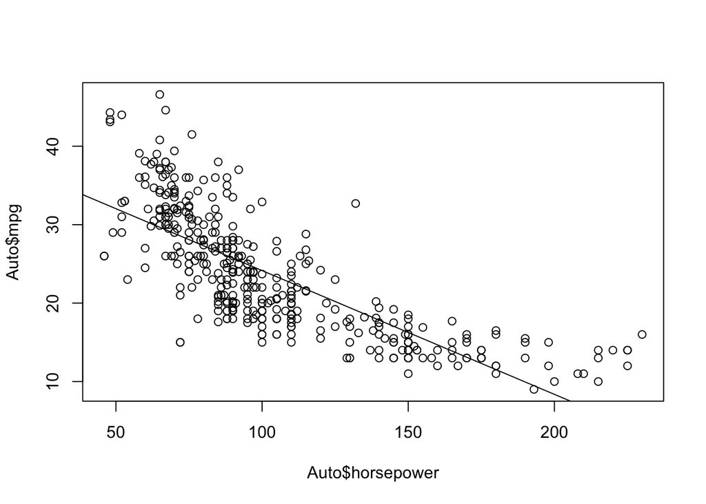

```r
# let's plot mpg as a function of horsepower
plot(Auto$horsepower, Auto$mpg)
abline(lm(Auto$mpg ~ Auto$horsepower, data=Auto))
```

You can clearly see that the relationship is not linear. It is close and for some applications it might be close enough, but it is not linear!

# Back to MTCARS

We can do the same thing with mtcars.

```r
# equation 5.7 for mtcars - our function to minimize
mtcars.fn=function(data, index) {
  return(coef(lm(mpg~hp, data=data, subset=index)))
}

# our linear model
mt = lm(mpg ~ hp, data=mtcars)
summary(mt)
```

```
##
## Call:
## lm(formula = mpg ~ hp, data = mtcars)
##
## Residuals:
##     Min      1Q  Median      3Q     Max
## -5.7121 -2.1122 -0.8854  1.5819  8.2360
##
## Coefficients:
##             Estimate Std. Error t value Pr(>|t|)
## (Intercept) 30.09886    1.63392  18.421  < 2e-16 ***
## hp          -0.06823    0.01012  -6.742 1.79e-07 ***
## ---
## Signif. codes:  0 '***' 0.001 '**' 0.01 '*' 0.05 '.' 0.1 ' ' 1
##
## Residual standard error: 3.863 on 30 degrees of freedom
## Multiple R-squared:  0.6024, Adjusted R-squared:  0.5892
## F-statistic: 45.46 on 1 and 30 DF,  p-value: 1.788e-07
```

```r
# now compute the bootstrap esimate.
boot(mtcars, mtcars.fn, R=1000)
```

```
##
## ORDINARY NONPARAMETRIC BOOTSTRAP
##
##
## Call:
## boot(data = mtcars, statistic = mtcars.fn, R = 1000)
##
##
## Bootstrap Statistics :
##        original       bias    std. error
## t1* 30.09886054  0.237294485  2.07762571
## t2* -0.06822828 -0.002250104  0.01389781
```

Notice that bootstrap and lm produce the same coefficients. Also, notice that the difference between the linear model and bootstrapping indicates some non-linearity in the mtcars dataset!

Again, this can be visualized.

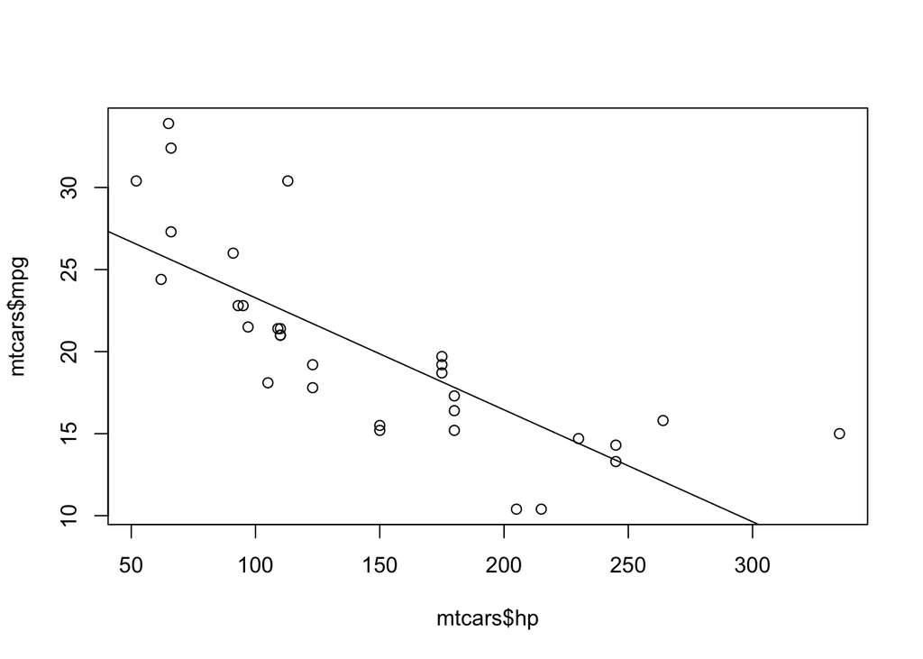

```r
plot(mtcars$hp, mtcars$mpg)
abline(lm(mtcars$mpg ~ mtcars$hp, data=mtcars))
```

# Conclusion

Mtcars and Auto are well-defined datasets. Modeling real world data is much more difficult. A key aspect of modeling is quantifying how accurate they are. Producing a Standard Error and Mean Squared Error for your real world model is the only way you can assess your work. Thus, you need those error estimates to be accurate.